# VERI MADENCILIGI VIZE

IremKoyunlu121517056

20 11 2020

# YAPAY SINIR AGLARI

## KAYNAK: https://www.kaggle.com/atulanandjha/national-stock-exchange-time-series

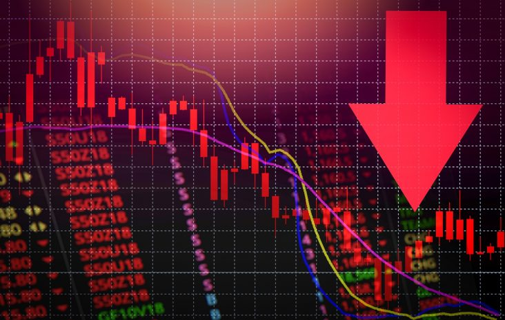

```r
library(dplyr)
orjdata=read.csv("C:/Users/CASPER/Desktop/infy_stock.csv", header=T)
data=orjdata%>%select(c("VWAP","Volume","High","Low","Close","Last"))
head(data,10)
```

```
##       VWAP   Volume    High     Low   Close    Last
## 1  1971.34   500691 1982.00 1956.90 1974.40 1971.00
## 2  2003.25  1694580 2019.05 1972.00 2013.20 2017.95
## 3  2004.59  2484256 2030.00 1977.50 1995.90 1996.00
## 4  1954.82  2416829 1985.00 1934.10 1954.20 1965.10
## 5  1962.59  1812479 1974.75 1950.00 1963.55 1966.05
## 6  1972.78  3391230 1997.00 1950.00 1973.45 1979.25
## 7  2037.69 11215832 2109.00 1913.05 2074.45 2075.30
## 8  2099.40  3189722 2119.20 2075.00 2115.95 2112.95
## 9  2089.42  2200309 2107.80 2075.00 2088.90 2092.00
## 10 2110.88  2480315 2133.00 2092.60 2128.65 2129.00
```

## VERI SETI ACIKLAMASI;

Ulusal Borsa:Hint bilisim sirketlerinin ulusal borsa veri setidir. Hindistan Ulusal Borsasi (NSE) Mumbai, Maharashtra, Hindistan’da bulunan bir Hint borsasidir. Ulusal Menkul Kiymetler Borsasi (NSE) 1992 yilinda yetkisiz bir elektronik borsa olarak kuruldu. Hindistan Hukumeti’nin talebi uzerine onde gelen finans kuruluslari tarafindan tesvik edildi. Hindistan’in ciro ile yaptigi en buyuk borsa. 1994 yilinda elektronik ekran tabanli ticareti baslatti. Daha sonra, 2000 yilinda ulkede turunun ilk ornegi olan endeks futures ve internet ticareti baslatti. 248 gozlem 15 sutun bulunmakta.

## DEGISKENLER:

- Date: Verilerin kaydedildigi tarih.
- Symbol: Stokun NSE (Hindistan Ulusal Borsasi ) sembolu.
- Series: Bu hisse senedinin serisi. (EQ,BE,BL,BT,GC,IL)
- Prev Close: Son gun kapanis noktasi.
- Open: Mevcut gun acilis noktasi.
- High: Mevcut gunun en yuksek noktasi.
- Low: Mevcut gunun en dusuk noktasi.
- Last: Son islem gununde belirli bir hisse senedi veya borsa endeksi icin son teklif edilen islem fiyati.
- Close: Gecerli gun icin kapanis noktasi.
- VWAP: Hacim agirlikli ortalama fiyat anlamina gelir, bir varligin belirli bir zaman araligi icin hacme gore agirligi alinmis ortalama fiyatidir.
- Volume: Belirli bir zaman diliminde islem goren menkul kiymet tutari. Her alici icin bir satici var ve her islem toplam hacim sayisina katkida bulunuyor.
- Turnover: Hisse senedinin o gune kadar toplam cirosu.
- Trades: Hisse senedi alim veya satim sayisi.
- Deliverable: Bir grup insandan (bugunden once demat hesabida bu hisseleri olan ve bugun satis yapan) baska bir grup insana (bu hisseleri satin almis olan ve bu hisseleri T+2 gunlerine kadar alacak olan) hareket eden hisse miktari. Demat hesabi(Hindistan Internet Borsasi)).
- %Deliverble: Bu hisse senedinin teslimat yuzdesi.

VWAP’yi ozellikle guclu bir gosterge haline getiren ortalama fiyat hesaplamasinda hacmi kullanma seklidir. VWAP, hacmin gucuyle fiyat hareketini birlestirerek pratik ve kullanimi kolay bir gosterge yaratir. Alim satim yapanlar VWAP’yi bir trend onaylama ya da giris ve cikis noktalarini belirleme araci olarak kullanabilir. VWAP her gunun basinda sifirlanir. Alim satim yapmak istedigimizde, VWAP’in altinda almak ve ustunde satmak karlidir. Fiyatin bugunku degerinin ustunde mi alim yaptik yoksa altinda mi alim yaptik bunu belirlememizi saglar. Fiyat VWAP uzerinde ise, satmak icin iyi bir gun ici fiyattir. Fiyat VWAP’in altindaysa, satin almak icin iyi bir gun ici fiyatidir.

Verimde yer alan degiskenlerden “VWAP”,“Volume”,“High”,“Low”,“Close”,“Last” degiskenlerini kullanarak incelemeler yaptim.

#### Degiskenleri Aciklamada Kullanilan Ek Bilgi Kaynaklari:

https://www.investopedia.com/articles/trading/11/trading-with-vwap-mvwap.asp https://www.binance.vision/tr/economics/volume-weighted-average-price-vwap-explained

Oncelikle verimizi ozetleyelim;

```r
summary(data)
```

```
##       VWAP            Volume              High             Low
##  Min.   : 941.2   Min.   :  353652   Min.   : 952.1   Min.   : 932.6
##  1st Qu.:1085.9   1st Qu.: 1722753   1st Qu.:1100.0   1st Qu.:1067.2
##  Median :1146.2   Median : 2532474   Median :1159.7   Median :1131.2
##  Mean   :1548.1   Mean   : 2982072   Mean   :1566.3   Mean   :1530.1
##  3rd Qu.:2125.1   3rd Qu.: 3567063   3rd Qu.:2150.0   3rd Qu.:2104.5
##  Max.   :2322.2   Max.   :19155056   Max.   :2336.0   Max.   :2292.1
##      Close             Last
##  Min.   : 937.5   Min.   : 935.5
##  1st Qu.:1085.9   1st Qu.:1086.9
##  Median :1149.3   Median :1145.6
##  Mean   :1548.0   Mean   :1548.1
##  3rd Qu.:2125.3   3rd Qu.:2125.2
##  Max.   :2324.7   Max.   :2323.2
```

Verimizin ozetine baktigimizda factor haline getirilecek degisken olmadigi gorulmektedir hatali bir durum yoktur.

Verimizde missing gozlemler var mi yok mu apply komutuyla kontrol etmeliyiz;

```r
apply(data,2,function(x) sum(is.na(x)))#Her sutunda kac tane missing gozlem var bunu gorecegiz. Hepsi sifir ise problem yok.
```

```
##   VWAP Volume   High    Low  Close   Last
##      0      0      0      0      0      0
```

Her sutunda kac tane missing gozlem var apply komutuyla goruluyor. Verimizin sutunlarina baktigimizda eksik gozlem olmadigi gozukmektedir bu nedenle bir problem yoktur.

Verimizin yanit degiskeni surekli oldugu icin standartlastirma islemi uygulamamiz gerekmektedir. Simdi sutunlarin maksimum ve minimum degerlerine bakalim;

```r
maxs <- apply(data, 2, max) #sutunlarin maksimum degerini verdi.
mins <- apply(data, 2, min) #sutunlarin minimum degerlerini verdi.
```

Center komutu ile verimizdeki tum gozlemlerden minimum degerini cikartip, Scale komutu ile degerleri maksimum-minimum degerine bolerek verimizi standart hale getirelim; Bu islem ile min-max normalization islemi yapiyoruz, bu islem verinin dagilimini ve yapisini bozmamaktadir.

```r
scaled <- as.data.frame(scale(data, center = mins, scale = maxs - mins))
head(scaled)
```

```
##        VWAP      Volume      High       Low     Close      Last
## 1 0.7459576 0.007820639 0.7442012 0.7534574 0.7474769 0.7461987
## 2 0.7690642 0.071320631 0.7709733 0.7645652 0.7754469 0.7800317
## 3 0.7700345 0.113321537 0.7788858 0.7686112 0.7629758 0.7642142
## 4 0.7339952 0.109735262 0.7463690 0.7366853 0.7329152 0.7419471
## 5 0.7396216 0.077591386 0.7389624 0.7483816 0.7396554 0.7426317
## 6 0.7470003 0.161561232 0.7550401 0.7483816 0.7467921 0.7521438
```

Simdi verimizi test ve train olarak ayiralim; Verimizden %75 lik orneklem cekerek bunu train ve kalan %25 lik kismiyla test veri setimizi olusturalim.

```r
set.seed(100)

index <- sample(1:nrow(data),round(0.75*nrow(data)))
train_ <- scaled[index,] #%75 lik kismini train olarak ayirdik
test_ <- scaled[-index,]
```

Verimizi test ve train olarak ayirdiktan sonra Yapay Sinir Agi modeli kuralim ;

```r
library(neuralnet) #Yapay sinir agi kutuphanesi
set.seed(100)

n <- names(train_) #traindeki degiskenlerin isimlerini aliyor.
f <- as.formula(paste("VWAP ~", paste(n[!n %in% "VWAP"], collapse = " + ")))#bu komut kolay yoldan model kurmamizi saglar.
nn <- neuralnet(f,data=train_,hidden=3,linear.output=T) #Yapay sinir agi modeli
```

Burada hidden komutu degisken sayimizin 2/3 u olarak alinir, hidden=3 almamizin sebebi yaniti etkileyen degiskenlerimizin sayisi 5 olmasindan kaynaklidir. Yanit dagiskenimiz surekli oldugundan linear.output degerini True alarak kullanmaliyiz.(Siniflandirma probleminde linear.output False alarak kullanilir.)

Simdi nn ile olusturdugumuz Yapay Sinig Agi modelini plot ile cizdirelim;

```r
plot(nn)
pr.nn <- compute(nn,test_[,2:6]) #VWAP (yanit degiskeni) disindaki degiskenleri modele sokuyor.
```

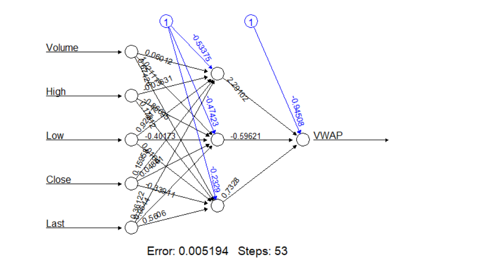

```r
knitr::include_graphics("plot(nn).png")
```

Yapay Sinir Agi icin cizdirdigimiz plota baktigimizda gizli katmaninda 3 tane noronun oldugu gozukmektedir. Error:0.005194 ve Stepst:53 cikmistir.

Bu degerler min-max normalization yapilmis haline gore hesaplanmistir. Simdi yaptigimiz min-max normalization islemini geri dondurme islemini yapmaliyiz.

```r
set.seed(100)
pr.nn_ <- pr.nn$net.result*(max(data$VWAP)-min(data$VWAP))+min(data$VWAP) #Geri dondurme islemi yapiyoruz.Min-max ile carpip min ekledik.
pr.nn_ #Verimizin orjinal tahminleri.
```

```
##          [,1]
## 3   2012.5388
## 6   1992.0515
## 9   2100.4076
## 17  2194.3074
## 23  2123.5164
## 29  2263.6646
## 33  2270.1252
## 34  2299.1205
## 36  2253.8479
## 38  2286.6383
## 54  2228.1872
## 56  2231.3226
## 57  2215.5376
## 59  2168.1045
```

[output cut: 48 more lines]

Simdi kurdugumuz Yapay Sinir Agi modeli icin test veri seti uzerinden MSE degerini hesaplayalim;

```r
MSE.nn <- sum((data[-index,]$VWAP - pr.nn_)^2)/nrow(test_)
MSE.nn
```

```
## [1] 106.2776
```

Yapay Sinir Agi modelimiz icin Test veri seti uzerinden hesaplanan MSE degerimiz 106.2776 cikmistir.

Verimizdeki yanit degiskenimiz VWAP in test veri seti uzerinden Gercek Ve Tahmin NN lerinin plotunu cizdirelim;

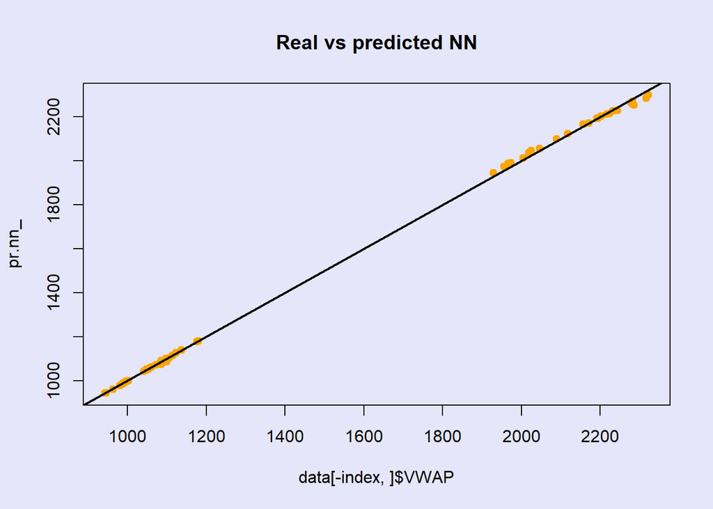

```r
op = par(bg = "lavender")
plot(data[-index,]$VWAP,pr.nn_,col='orange',main='Real vs predicted NN',pch=19,cex=1)
abline(0,1,lwd=2)
```

Test verisinin gercek degerleri(x ekseni) ve ANN uzerinden tahmin edilen degerleri(y ekseni) uzerinde gozukmektedir. Verimizdeki yanit degiskenimiz VWAP in test veri seti uzerinden Gercek Ve Tahmin NN lerinin plotuna baktigimizda cogu degiskenim dogru tahmin edilmistir. Yapay Sinir Agi tahminleri ile Orijinal veri seti degerlerim uyumlu cikmistir.

Simdi Yapay Sinir Agi modelimizi hidden=c(4,3) komutu ile iki katmanli olarak kuralim. Ilk katmanda 4 noron ve ikinci katmanda 3 noron kullanarak inceleyelim;

```r
set.seed(100)

nn1 <- neuralnet(f,data=train_,hidden=c(4,3),linear.output=T)
```

Simdi nn1 ile olusturdugumuz Yapay Sinig Agi modelini plot ile cizdirelim;

```r
plot(nn1)
pr.nn1 <- compute(nn1,test_[,2:6])#VWAP (yanit degiskeni) disindaki degiskenleri modele sokuyor.
```

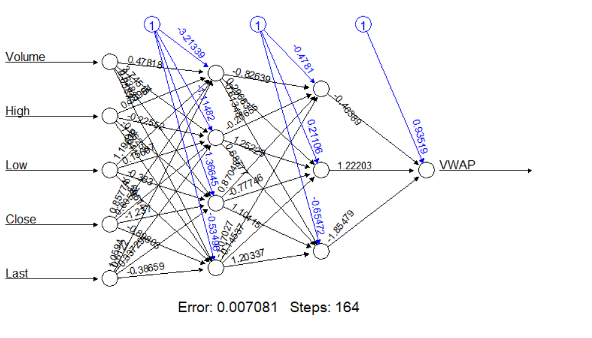

```r
knitr::include_graphics("plot(nn1).png")
```

Yapay Sinir Agi icin cizdirdigimiz plota baktigimizda ilk gizli katmaninda 4 tane noronun oldugu ve ikinci gizli katmaninda 3 noron oldugu gozukmektedir. Error:0.007081 ve Stepst:164 cikmistir.

Bu degerler min-max normalization yapilmis haline gore hesaplanmistir. Simdi yaptigimiz min-max normalization islemini geri dondurme islemini yapmaliyiz.

```r
set.seed(100)

pr.nn1 <- pr.nn1$net.result*(max(data$VWAP)-min(data$VWAP))+min(data$VWAP)
pr.nn1
```

```
##          [,1]
## 3   2011.3380
## 6   1983.4604
## 9   2099.8811
## 17  2201.8751
## 23  2129.6680
## 29  2263.0985
## 33  2268.5608
## 34  2290.5646
## 36  2257.0532
## 38  2286.8484
## 54  2225.4114
## 56  2233.4935
## 57  2216.0758
## 59  2163.2681
```

[output cut: 48 more lines]

Simdi kurdugumuz bu iki katmanli Yapay Sinir Agi modeli icin test veri seti uzerinden MSE degerini hesaplayalim;

```r
MSE.nn1 <- sum((data[-index,]$VWAP - pr.nn1)^2)/nrow(test_)
MSE.nn1
```

```
## [1] 216.3786
```

Iki katmanli Yapay Sinir Agi modelimiz icin Test veri seti uzerinden hesaplanan MSE degerimiz 216.3786 cikmistir.

Baktigimiz tek katmanli Yapay Sinir Agi modelimizin yani ilk modelin MSE si daha dusuk gelmistir.(106.2776) Acaba bu durum gercekten tek katmanli Yapay Sinir Agi modelimizin yani ilk modelin daha iyi oldugunu mu gosterir? Acaba test verisini farkli secseydikte ayni durum soz konusu olur muydu ? Bu amacla Cross Validation yapmak daha sagliklidir.

Simdi ilk olarak ilk modelin daha sonra ikinci modelin Cross Validation Errorlarini hesaplayalim;

```r
set.seed(100)
cv.error1 <- NULL
cv.error2 <- NULL
k <- 10

for(i in 1:k){index <- sample(1:nrow(scaled),round(0.9*nrow(scaled)))
train.cv <- scaled[index,]
test.cv <- scaled[-index,]
nn <- neuralnet(f,data=train.cv,hidden=3,linear.output=T)
nn1 <- neuralnet(f,data=train.cv,hidden=c(4,3),linear.output=T)
pr.nn <- compute(nn,test.cv[,2:6])
pr.nn <- pr.nn$net.result*(max(data$VWAP)-min(data$VWAP))+min(data$VWAP)
pr.nn1 <- compute(nn1,test.cv[,2:6])
pr.nn1 <- pr.nn1$net.result*(max(data$VWAP)-min(data$VWAP))+min(data$VWAP)
test.cv.r <- data[-index,]$VWAP
cv.error1[i] <- sum((test.cv.r - pr.nn)^2)/nrow(test.cv)
cv.error2[i] <- sum((test.cv.r - pr.nn1)^2)/nrow(test.cv)
}
```

Tek katmanli Yapay Sinir Agi modelimizin yani ilk modelin 10 foldluk Cross Validation Error degerlerini hesaplayalim;

```r
cv.error1
```

```
##  [1] 161.98709  78.02244 136.04502 181.51638  54.77414 210.80789  82.06800
##  [8] 166.55390  69.71994 233.30501
```

Iki katmanli Yapay Sinir Agi modelimizin yani ikinci modelin 10 foldluk Cross Validation Error degerlerini hesaplayalim;

```r
cv.error2
```

```
##  [1]  60.42740 158.78913  31.40556  76.92808  33.69955 332.57308  18.82481
##  [8] 240.95270 224.11872  83.31608
```

```r
mean(cv.error1)
```

```
## [1] 137.48
```

Tek katmanli Yapay Sinir Agi modelimizin yani ilk modelin 10 foldluk Cross Validation Error degerlerinin ortalamasi 137.48 cikmistir.

```r
mean(cv.error2)
```

```
## [1] 126.1035
```

Iki katmanli Yapay Sinir Agi modelimizin yani ikinci modelin 10 foldluk Cross Validation Error degerlerinin ortalamasi 126.1035 cikmistir.

Cross Validation sonucumuza gore iki katmanli Yapay Sinir Agi modelimizin yani ikinci modelin 10 foldluk Cross Validation Error degerlerinin ortalamasi daha dusuk cikmistir.Simdi ikinci modelin daha iyi oldugunu soyleyebiliriz.

Simdi de Yapay Sinir Agi modellerimiz uzerinden Cross Validation ile hesaplanan Error degerlerimizin Boxplotunu cizdirelim;

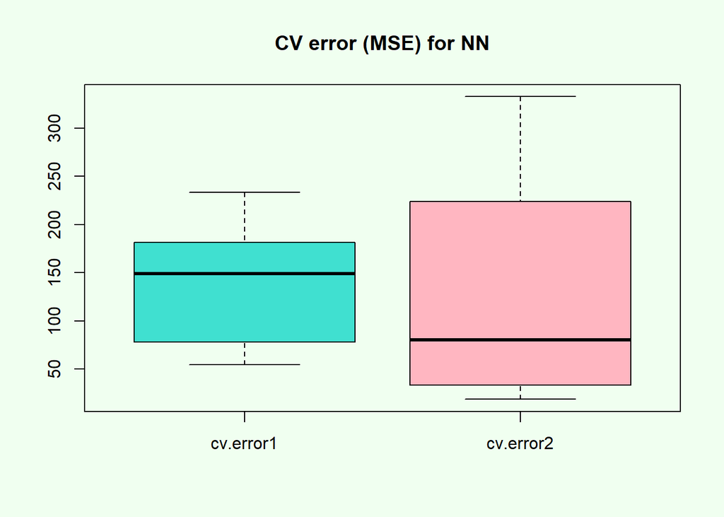

```r
op = par(bg = "honeydew")
boxplot(cv.error1,cv.error2, names=c("cv.error1","cv.error2"),main="CV error (MSE) for NN",horizontal=FALSE,col=c("turquoise","lightpink"))
```

Yapay Sinir Agi modellerimiz uzerinden Cross Validation ile hesaplanan Error degerlerimizin Boxplotuna baktigimizda cv.error2 nin saga carpik dagilima sahip oldugu gozukmektedir.

Simdi verimizdeki tahmin dogruluguna en cok katki sunan degiskeni gormek icin grafik cizdirelim;

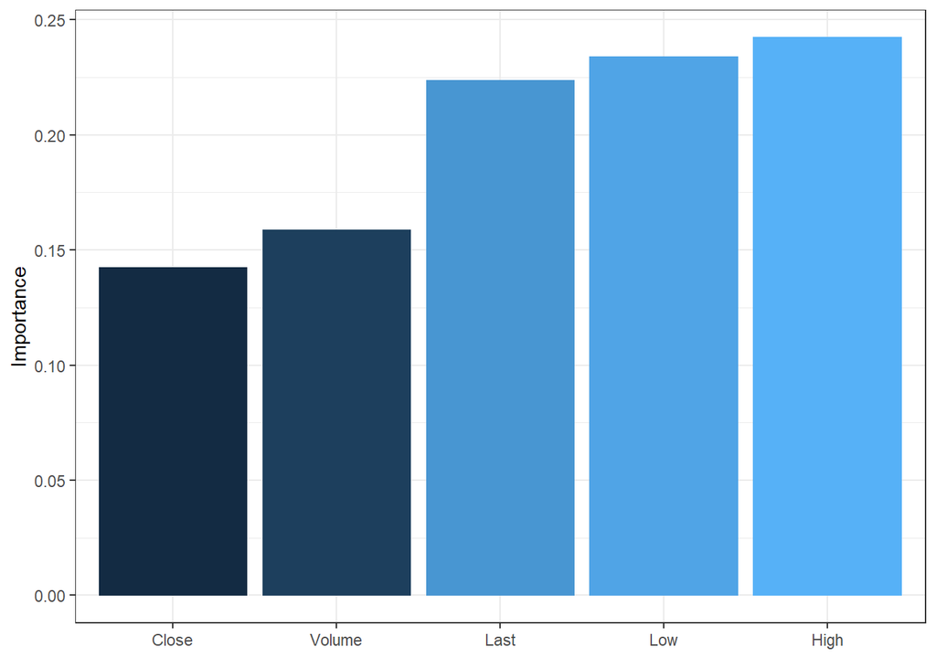

```r
library(NeuralNetTools)
set.seed(100)
nn <- neuralnet(f,data=train_,hidden=3,linear.output=F)
garson(nn)
```

Bu veri setindeki tahmin dogruluguna en cok katki sunan degisken olarak gozuken “High”(Mevcut gunun en yuksek noktasi) degiskendir.

# YAPAY SINIR AGLARINDA SINIFLANDIRMA

## KAYNAK:https://www.kaggle.com/abhia1999/chronic-kidney-disease?select=new_model.csv

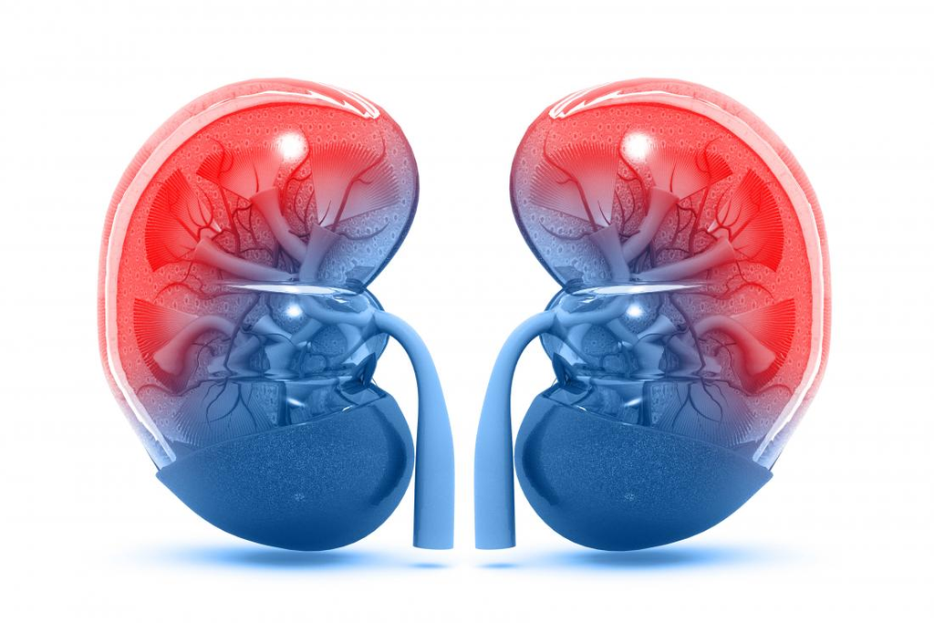

```r
library(dplyr)
orj=read.csv("C:/Users/CASPER/Desktop/new_model.csv", header=T)
veri=orj%>%select(c("Bp","Sg","Bu","Sc","Sod","Pot","Hemo","Wbcc","Rbcc","Class"))
```

## VERI SETI ACIKLAMASI ;

Bu veri kumesi, orijinal olarak UCI Makine Ogrenimi Havuzundan alinmistir. Veri setinin amaci, bir hastanin kronik bobrek hastaligina sahip olup olmadigini,veri setine dahil edilen belirli tanisal olcumlere dayanarak tahmin etmektir. Veri kumesi, birkac tibbi ongorucu degisken ve bir hedef degisken olan Class’tan olusur.

Kronik bobrek hastaligi , bobrek islevinin uzun bir surecte ilerleyici kaybi ile karaterizedir. Bu islev kaybi kritik bir duzeye ulastiginda tum organlarini etkileyen ciddi saglik sorunlari ortaya cikmaktadir. Kronik bobrek hastalarinda olum ve ozurluluk riskleri saglikli bireylerden 10-30 kat daha yuksektir. Bu durumun yol actigi kotu yasam kalitesi hastalarin aile ve sosyal yasantilarini da olumsuz yonde etkilemektedir. Kronik bobrek hastaligi siklikla son evreye kadar sessiz bir sekilde ilerlemektedir genellikle erken evrelerde belirti vermemektedir.Bu nedenle hastalara erken evrelerde tani konulamamaktadir.Bunun dogal sonucu olarak bobrek hasarini onleyecek tedaviler icin cok gec kalinmakta, hastalar hizli ve dramatik olarak son evreye ilerlemektedirler.

Oncelikle verimizi ozetleyelim;

```r
summary(veri)
```

```
##        Bp               Sg              Bu               Sc
##  Min.   : 50.00   Min.   :1.005   Min.   :  1.50   Min.   : 0.400
##  1st Qu.: 70.00   1st Qu.:1.015   1st Qu.: 27.00   1st Qu.: 0.900
##  Median : 78.00   Median :1.020   Median : 44.00   Median : 1.400
##  Mean   : 76.45   Mean   :1.018   Mean   : 57.41   Mean   : 3.072
##  3rd Qu.: 80.00   3rd Qu.:1.020   3rd Qu.: 61.75   3rd Qu.: 3.070
##  Max.   :180.00   Max.   :1.025   Max.   :391.00   Max.   :76.000
##       Sod             Pot              Hemo            Wbcc
##  Min.   :  4.5   Min.   : 2.500   Min.   : 3.10   Min.   : 2200
##  1st Qu.:135.0   1st Qu.: 4.000   1st Qu.:10.88   1st Qu.: 6975
##  Median :137.5   Median : 4.630   Median :12.53   Median : 8406
##  Mean   :137.5   Mean   : 4.628   Mean   :12.53   Mean   : 8406
##  3rd Qu.:141.0   3rd Qu.: 4.800   3rd Qu.:14.62   3rd Qu.: 9400
##  Max.   :163.0   Max.   :47.000   Max.   :17.80   Max.   :26400
##       Rbcc           Class
##  Min.   :2.100   Min.   :0.000
##  1st Qu.:4.500   1st Qu.:0.000
##  Median :4.710   Median :1.000
##  Mean   :4.708   Mean   :0.625
##  3rd Qu.:5.100   3rd Qu.:1.000
##  Max.   :8.000   Max.   :1.000
```

Verimizin ozetine baktigimizda Class degiskenimizi factor haline getirmeliyiz.

```r
veri$Class[which(veri$Class==1)]<- "Hasta"
veri$Class[which(veri$Class==0)]<- "HastaDegil"
```

Verimizdeki Class degiskeninde 1 olanlari “Hasta” ve 0 olanlari “HastaDegil” olarak isimlendirdik.

Class degiskenimizi factor haline getirelim;

```r
veri$Class<-factor(veri$Class)
summary(veri)
```

```
##        Bp               Sg              Bu               Sc
##  Min.   : 50.00   Min.   :1.005   Min.   :  1.50   Min.   : 0.400
##  1st Qu.: 70.00   1st Qu.:1.015   1st Qu.: 27.00   1st Qu.: 0.900
##  Median : 78.00   Median :1.020   Median : 44.00   Median : 1.400
##  Mean   : 76.45   Mean   :1.018   Mean   : 57.41   Mean   : 3.072
##  3rd Qu.: 80.00   3rd Qu.:1.020   3rd Qu.: 61.75   3rd Qu.: 3.070
##  Max.   :180.00   Max.   :1.025   Max.   :391.00   Max.   :76.000
##       Sod             Pot              Hemo            Wbcc
##  Min.   :  4.5   Min.   : 2.500   Min.   : 3.10   Min.   : 2200
##  1st Qu.:135.0   1st Qu.: 4.000   1st Qu.:10.88   1st Qu.: 6975
##  Median :137.5   Median : 4.630   Median :12.53   Median : 8406
##  Mean   :137.5   Mean   : 4.628   Mean   :12.53   Mean   : 8406
##  3rd Qu.:141.0   3rd Qu.: 4.800   3rd Qu.:14.62   3rd Qu.: 9400
##  Max.   :163.0   Max.   :47.000   Max.   :17.80   Max.   :26400
##       Rbcc              Class
##  Min.   :2.100   Hasta     :250
##  1st Qu.:4.500   HastaDegil:150
##  Median :4.710
##  Mean   :4.708
##  3rd Qu.:5.100
##  Max.   :8.000
```

Verimizin ozetine baktigimizda verimizde 250 tane hasta ve 150 tane hasta olmayan gozlem oldugunu gormekteyiz.

Verimizde missing gozlemler var mi yok mu apply komutuyla kontrol etmeliyiz;

```r
apply(veri,2,function(x) sum(is.na(x)))
```

```
##    Bp    Sg    Bu    Sc   Sod   Pot  Hemo  Wbcc  Rbcc Class
##     0     0     0     0     0     0     0     0     0     0
```

Her sutunda kac tane missing gozlem var apply komutuyla goruluyor. Verimizin sutunlarina baktigimizda eksik gozlem olmadigi gozukmektedir bu nedenle bir problem yoktur.

Verimizin yanit degiskeni kesikli oldugu icin standartlastirma islemini yanit degiskeni haricindeki bagimsiz degiskenlere uygulamamiz gerekmektedir. Simdi sutunlarin maksimum ve minimum degerlerine bakalim;

Burada yanit degiskenimiz kesikli oldugundan min-max normalization isleminde yer almaz. Yanit degiskenim 10. sutunda oldugu icin 1 den 9 a kadar olan sutunlari alalim;

```r
maxs <- apply(veri[ ,1:9], 2, max) #Sutunlarin maksimum degerini verir.
mins <- apply(veri[ ,1:9], 2, min) #Sutunlar,n minimum degerini verir.
```

Center komutu ile verimizdeki tum gozlemlerden minimum degerini cikartip, Scale komutu ile degerleri maksimum-minimum degerine bolerek verimizi standart hale getirelim; Bu islem ile min-max normalization islemi yapiyoruz, bu islem verinin dagilimini ve yapisini bozmamaktadir.

```r
scaled <- data.frame(as.data.frame(scale(veri[,1:9], center = mins, scale = maxs-mins)),veri$Class)
```

Burada normalization uyguladigimiz numeric degiskenler ile kategorik olan bagimli degiskeni birlestirmek icin data.frame kodunu kullandik.

Simdi verimizi test ve train olarak ayiralim; Verimizden %75 lik orneklem cekerek bunu train ve kalan %25 lik kismiyla test veri setimizi olusturalim.

```r
set.seed(123)
index <- sample(1:nrow(veri),0.75*nrow(veri))
train <- scaled[index,]
test <- scaled[-index,]
```

Cikis katmanindaki noron sayisi, kac tane ikili ciktinin ogrenilmesi gerektigine baglidir.Bir siniflandirma probleminde, bu tipik olarak cikti kategorisindeki olasi degerlerin sayisidir. Bu amacla yanit degiskenimizi asagidaki gibi duzenleyecegiz.

Bu kod ile Yapay Sinir Agi modelimizde 2 cikti olacak.(Hasta ve HastaDegil)

```r
nntrain<-train

nntrain <- cbind(nntrain, train$veri.Class == "Hasta")
nntrain <- cbind(nntrain, train$veri.Class == "HastaDegil")
names(nntrain)[11] <- "Hasta"
names(nntrain)[12] <- "HastaDegil"
head(nntrain)
```

```
##             Bp   Sg         Bu          Sc       Sod        Pot      Hemo
## 179 0.30769231 0.75 0.38896021 0.030423280 0.8485804 0.04044944 0.4557823
## 14  0.15384615 0.75 0.21694480 0.055555556 0.8233438 0.02022472 0.4557823
## 195 0.15384615 0.25 0.12195122 0.010582011 0.8393060 0.04786517 0.6414966
## 306 0.23076923 0.75 0.06033376 0.005291005 0.8422713 0.05617978 0.9523810
## 118 0.15384615 0.75 0.08857510 0.011904762 0.8485804 0.02696629 0.6394558
## 299 0.07692308 0.75 0.12195122 0.010582011 0.8233438 0.04494382 0.7074830
##          Wbcc      Rbcc veri.Class Hasta HastaDegil
## 179 0.3140496 0.4423729      Hasta  TRUE      FALSE
## 14  0.2564463 0.4423729      Hasta  TRUE      FALSE
## 195 0.2564463 0.4423729      Hasta  TRUE      FALSE
## 306 0.2851240 0.5254237 HastaDegil FALSE       TRUE
## 118 0.3140496 0.3898305      Hasta  TRUE      FALSE
## 299 0.2644628 0.4745763 HastaDegil FALSE       TRUE
```

Bu kod ile verimize Hasta ve HastaDegil adinda iki sutun ekledik. Classta Hasta olan gozlemler hasta sutununda TRUE, HastaDegil sutununda FALSE olarak gostermektedir. Ayni sekilde Classta HastaDegil olan gozlemler Hasta sutununda FALSE, HastaDegil sutununda TRUE olarak gostermektedir.

Simdi Yapay Sinir Agi Modeli olusturmaya baslayalim;

Hidden noron sayisini ve katman sayisini belirlemek icin kullanilir. Default olarak hidden=1 alinir. Genellikle tek bir katman olmasi yeterlidir. Degisken sayisinin 2/3 u noron sayisini verir. Verimizde degisken sayisi 10 oldugundan hidden=7 olarak kullanilir. Amacimiz siniflandirma oldugundan linear.output=FALSE kullanacagiz.

```r
set.seed(1234)
library(neuralnet)
ANN <- neuralnet( Hasta + HastaDegil ~ Bp + Sg + Bu + Sc + Sod + Pot + Hemo + Wbcc + Rbcc,data=nntrain,hidden=7,linear.output=F)
plot(ANN)
```

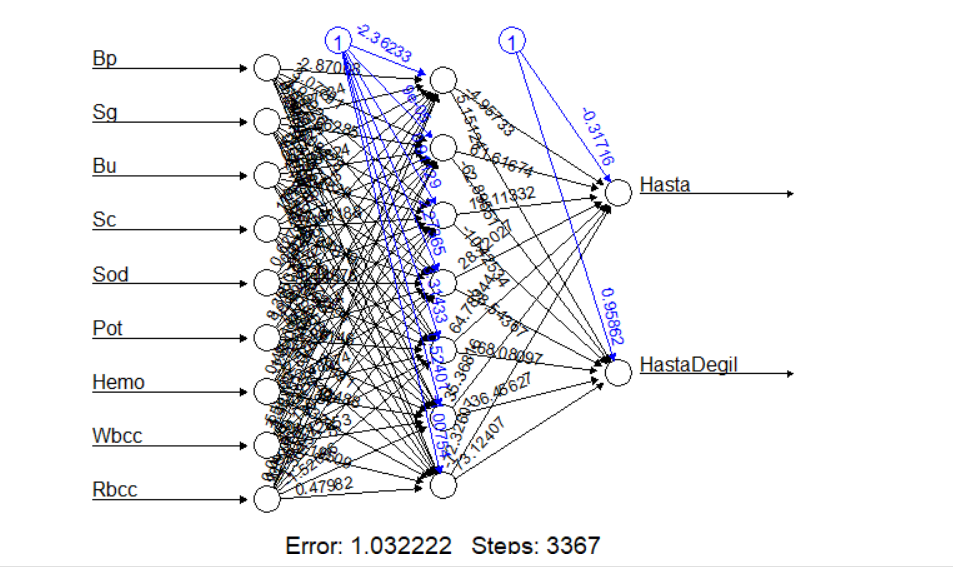

```r
knitr::include_graphics("plot(ANN).png")
```

Yapay Sinir Agi icin cizdirdigimiz plota baktigimizda gizli katmaninda 7 tane noronun oldugu gozukmektedir. Error:1.032222 ve Stepst:3367 cikmistir.

Prediction asamasinda geriye donus yapmadik. Cunku yanit degiskenimiz kesikli oldugundan normalizasyon uygulamadik. Burada tahmin degerleri 0.5 ten buyuk ise “Hasta” , degil ise “HastaDegil” girilecek.

```r
pred = ifelse((predict(ANN,test[,-10])>0.5)[,1]=="TRUE","Hasta","HastaDegil")
pred
```

```
##            1            3            6            8           15           17
## "HastaDegil"      "Hasta"      "Hasta"      "Hasta"      "Hasta"      "Hasta"
##           18           19           28           38           44           46
##      "Hasta" "HastaDegil"      "Hasta"      "Hasta"      "Hasta"      "Hasta"
##           49           56           58           59           60           62
##      "Hasta"      "Hasta"      "Hasta"      "Hasta"      "Hasta"      "Hasta"
##           65           68           70           71           75           79
##      "Hasta"      "Hasta" "HastaDegil" "HastaDegil"      "Hasta"      "Hasta"
##           88           95           97           99          100          103
##      "Hasta"      "Hasta"      "Hasta"      "Hasta"      "Hasta"      "Hasta"
##          108          114          119          120          123          124
##      "Hasta"      "Hasta"      "Hasta"      "Hasta"      "Hasta"      "Hasta"
##          126          128          131          132          138          139
##      "Hasta"      "Hasta"      "Hasta"      "Hasta"      "Hasta"      "Hasta"
##          144          147          149          156          167          169
##      "Hasta"      "Hasta"      "Hasta"      "Hasta"      "Hasta"      "Hasta"
##          170          171          175          176          180          181
##      "Hasta"      "Hasta"      "Hasta"      "Hasta"      "Hasta"      "Hasta"
##          188          189          190          191          206          207
##      "Hasta"      "Hasta"      "Hasta"      "Hasta"      "Hasta"      "Hasta"
##          208          219          225          234          237          246
##      "Hasta"      "Hasta"      "Hasta"      "Hasta"      "Hasta"      "Hasta"
##          248          259          268          270          274          281
## "HastaDegil" "HastaDegil" "HastaDegil" "HastaDegil" "HastaDegil" "HastaDegil"
##          283          284          289          301          303          304
## "HastaDegil" "HastaDegil" "HastaDegil" "HastaDegil" "HastaDegil" "HastaDegil"
##          305          310          318          327          329          334
## "HastaDegil" "HastaDegil" "HastaDegil" "HastaDegil" "HastaDegil" "HastaDegil"
##          335          338          342          345          356          358
## "HastaDegil" "HastaDegil" "HastaDegil" "HastaDegil" "HastaDegil" "HastaDegil"
##          360          367          369          371          375          386
## "HastaDegil" "HastaDegil" "HastaDegil" "HastaDegil" "HastaDegil" "HastaDegil"
##          387          394          396          400
## "HastaDegil" "HastaDegil" "HastaDegil" "HastaDegil"
```

Simdi Confusion Matrixi elde edelim ;

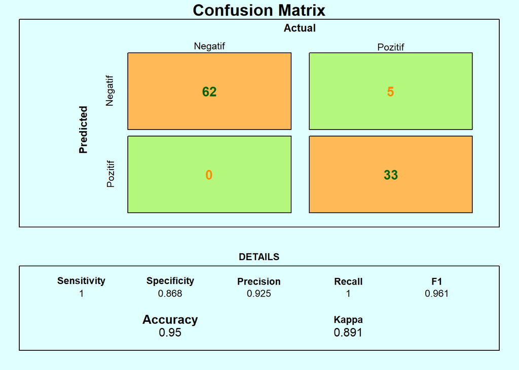

```r
library(caret)
library(e1071)

cm <- confusionMatrix(table(test[,10], pred))
draw_confusion_matrix <- function(cm) {
layout(matrix(c(1,1,2)))
par(mar=c(2,2,2,2))
plot(c(100, 345), c(300, 450), type = "n", xlab="", ylab="", xaxt='n', yaxt='n')
title('Confusion Matrix', cex.main = 2)
rect(150, 430, 240, 370, col = '#ffb957')
text(195, 435, 'Negatif', cex = 1.2)
rect(250, 430, 340, 370, col = '#b3f77c')
text(295, 435, 'Pozitif', cex = 1.2)
text(125, 370, 'Predicted', cex = 1.3, srt = 90, font = 2)
text(245, 450, 'Actual', cex=1.3, font=2)
rect(150, 305, 240, 365, col = '#b3f77c')
rect(250, 305, 340, 365, col = '#ffb957')
text(140, 400, 'Negatif', cex = 1.2, srt = 90)
text(140, 335, 'Pozitif', cex = 1.2, srt = 90)
res <- as.numeric(cm$table)
text(195, 400, res[1], cex = 1.6, font = 2, col = 'darkgreen')
text(195, 335, res[2], cex = 1.6, font = 2, col = 'darkorange')
text(295, 400, res[3], cex = 1.6, font = 2, col = 'darkorange')
text(295, 335, res[4], cex = 1.6, font = 2, col = 'darkgreen')
plot(c(100, 0), c(100, 0), type = "n", xlab="", ylab="", main = "DETAILS", xaxt = 'n', yaxt = 'n')
text(10, 85, names(cm$byClass[1]), cex=1.2, font=2)
text(10, 70, round(as.numeric(cm$byClass[1]), 3), cex=1.2)
text(30, 85, names(cm$byClass[2]), cex=1.2, font=2)
text(30, 70, round(as.numeric(cm$byClass[2]), 3), cex=1.2)
text(50, 85, names(cm$byClass[5]), cex=1.2, font=2)
text(50, 70, round(as.numeric(cm$byClass[5]), 3), cex=1.2)
text(70, 85, names(cm$byClass[6]), cex=1.2, font=2)
text(70, 70, round(as.numeric(cm$byClass[6]), 3), cex=1.2)
text(90, 85, names(cm$byClass[7]), cex=1.2, font=2)
text(90, 70, round(as.numeric(cm$byClass[7]), 3), cex=1.2)
text(30, 35, names(cm$overall[1]), cex=1.5, font=2)
text(30, 20, round(as.numeric(cm$overall[1]), 3), cex=1.4)
text(70, 35, names(cm$overall[2]), cex=1.2, font=2)
text(70, 20, round(as.numeric(cm$overall[2]), 3), cex=1.4)
}
op = par(bg = "lightcyan")
draw_confusion_matrix(cm)
```

Elde ettigimiz Confusion Matrixi’e baktigimizda;

Yukarida da goruldugu gibi Accuracy degerimiz 0.95, Sensitivity degerimiz 1 ve Kappa degerimiz 0.891 cikmistir.

# SUPPORT VECTOR MACHINES

Ilk olarak verimizi test ve train olarak ikiye ayiralim. Bunun iCin sample.split komutunu kullanacagiz. Bu komut icin “caTools” kutuphanesini ilk olarak indirelim.  
Verimiz cok dengesiz oldugundan (unblanced) daha dengeli bir kismini secip o kisim uzerinde calisalim.

Simdi verimizin %80 ini train ve %20 sini test olarak ayiralim;

```r
library(caTools)
set.seed(200)

veri<-veri[101:400,] #Kategorik degiskenimiz uzerinden dengeli bir sekilde veriyi ayiralim.
summary(veri)
```

```
##        Bp               Sg              Bu               Sc
##  Min.   : 50.00   Min.   :1.005   Min.   :  1.50   Min.   : 0.400
##  1st Qu.: 70.00   1st Qu.:1.015   1st Qu.: 26.00   1st Qu.: 0.875
##  Median : 76.00   Median :1.020   Median : 40.00   Median : 1.200
##  Mean   : 75.03   Mean   :1.019   Mean   : 52.92   Mean   : 2.613
##  3rd Qu.: 80.00   3rd Qu.:1.025   3rd Qu.: 57.00   3rd Qu.: 2.500
##  Max.   :120.00   Max.   :1.025   Max.   :322.00   Max.   :48.100
##       Sod             Pot              Hemo            Wbcc
##  Min.   :113.0   Min.   : 2.500   Min.   : 3.10   Min.   : 2200
##  1st Qu.:136.0   1st Qu.: 3.900   1st Qu.:11.50   1st Qu.: 6800
##  Median :137.5   Median : 4.630   Median :13.20   Median : 8406
##  Mean   :138.6   Mean   : 4.566   Mean   :13.04   Mean   : 8338
##  3rd Qu.:142.0   3rd Qu.: 4.900   3rd Qu.:15.00   3rd Qu.: 9400
##  Max.   :150.0   Max.   :47.000   Max.   :17.80   Max.   :26400
##       Rbcc              Class
##  Min.   :2.100   Hasta     :150
##  1st Qu.:4.700   HastaDegil:150
##  Median :4.710
##  Mean   :4.853
##  3rd Qu.:5.300
##  Max.   :8.000
```

```r
split = sample.split(veri$Class, SplitRatio = 0.80)

training_set = subset(veri, split == TRUE)
test_set = subset(veri, split == FALSE)
```

SVM icin “e1071” kutuphanesini indirelim ve training set uzerinde SVM siniflandiricisini kuralim.

Yanit degiskenimiz kategorik oldugundan type olarak C-classification sececegiz.

Cost degeri icin default olarak 1 secili (cost = 1) istersek degistirebiliriz.(Cost:soft marjin classifier da marjinlerin arasinda kalan gozlemler icin odenen bedel idi.)

```r
library(e1071)
classifier1 = svm(formula = Class ~ .,
                 data = training_set,scale=TRUE,
                 type = 'C-classification',
                 kernel = 'linear') #Linear ayristirma kullaniyoruz.
```

Simdi test kumemizdeki tahminlerimizi elde edelim;

```r
y_pred1 <- predict(classifier1, newdata = test_set[-10])
cmlinear1 <- table(test_set[,10], y_pred1)
```

Simdi test kumemizdeki tahminlerimizden elde ettigimiz Confusion Matriximizi olusturalim.

```r
set.seed(12)
library(caret)
cm1 <- confusionMatrix(table(test_set[,10], y_pred1))
cm1
```

```
## Confusion Matrix and Statistics
##
##             y_pred1
##              Hasta HastaDegil
##   Hasta         28          2
##   HastaDegil     1         29
##
##                Accuracy : 0.95
##                  95% CI : (0.8608, 0.9896)
##     No Information Rate : 0.5167
##     P-Value [Acc > NIR] : 1.837e-13
##
##                   Kappa : 0.9
##
##  Mcnemar's Test P-Value : 1
##
##             Sensitivity : 0.9655
##             Specificity : 0.9355
##          Pos Pred Value : 0.9333
##          Neg Pred Value : 0.9667
##              Prevalence : 0.4833
##          Detection Rate : 0.4667
##    Detection Prevalence : 0.5000
##       Balanced Accuracy : 0.9505
##
##        'Positive' Class : Hasta
##
```

Bu matrise baktigimizda; Gercek veride 30 tane Hasta var iken model bunlardan 28 tanesini dogru, 2 tanesini yanlis tahmin etmistir. Gercek veride 30 tane HastaDegil var iken model bunlardan 29 tanesini dogru, 1 tanesini yanlis tahmin etmistir. Ayni zamanda bu tahmin ile Accuracy degerimiz 0.95 , Kappa degerimiz 0.9 ve Sensitivity degerimiz 0.9655 cikmistir.

Confusion matris uzerinden dogru tahmin oranini hesaplayalim;

```r
accuracylinear1=(cmlinear1[1,1]+cmlinear1[2,2])/dim(test_set)[1]
accuracylinear1
```

```
## [1] 0.95
```

Confusion matris uzerinden dogru tahmin orani 0.95 cikmistir.

SVM’in basarisi secilen parametrelere cok baglidir. Bu yuzden bu parametrelerin secimi icin cross validation kullanilmasi daha dogru bir yaklasim olacaktir. Farkli secimlerle daha yuksek bir tahmin performansi elde edip edemeyecegimizi inceleyelim. Bu amacla tune.svm komutunu kullanacagiz.Ilk olarak linear kernel ile devam edip sadece cost parametresi icin cross validation yapalim.

```r
set.seed(12)
tune.out<-tune.svm(Class ~ ., data = training_set,kernel='linear',cost= c(0.5,1,5,10))
summary(tune.out)
```

```
##
## Parameter tuning of 'svm':
##
## - sampling method: 10-fold cross validation
##
## - best parameters:
##  cost
##   0.5
##
## - best performance: 0.03333333
##
## - Detailed performance results:
##   cost      error dispersion
## 1  0.5 0.03333333 0.03286711
## 2  1.0 0.03750000 0.03648313
## 3  5.0 0.04166667 0.03928371
## 4 10.0 0.04166667 0.03928371
```

10 fold Cross Validation yapip Cost icin 4 degere baktigimiz da en az error degerine sahip cost degeri 0.5 cikmistir. Cost degerinin 0.5’i icin best performance: 0.03333 (yani cross validation ile yapilan error degeri) cikmistir.

Bu ciktidaki dispersion sutunu, ilgili parametre secimleri icin foldlardan elde edilen siniflandirma hatalarinin standart sapmasini gostermektedir.

Simdi cross validation ile belirledigimiz cost parametresini kullanarak yeni SVM siniflandiricisini kuralim.

```r
classifier2 = svm(formula = Class ~ .,
                 data = training_set,scale=TRUE,
                 type = 'C-classification', cost=0.5,
                 kernel = 'linear') #Linear ayristirma kullaniyoruz.
```

Simdi test kumemizdeki tahminlerimizi elde edelim;

```r
y_pred2 = predict(classifier2, newdata = test_set[-10])

cmlinear2 = table(test_set[,10], y_pred2)
```

Simdi test kumemizdeki tahminlerimizden elde ettigimiz Confusion Matriximizi olusturalim.

```r
set.seed(12)
library(caret)
cm2 <- confusionMatrix(table(test_set[,10], y_pred2))
cm2
```

```
## Confusion Matrix and Statistics
##
##             y_pred2
##              Hasta HastaDegil
##   Hasta         28          2
##   HastaDegil     1         29
##
##                Accuracy : 0.95
##                  95% CI : (0.8608, 0.9896)
##     No Information Rate : 0.5167
##     P-Value [Acc > NIR] : 1.837e-13
##
##                   Kappa : 0.9
##
##  Mcnemar's Test P-Value : 1
##
##             Sensitivity : 0.9655
##             Specificity : 0.9355
##          Pos Pred Value : 0.9333
##          Neg Pred Value : 0.9667
##              Prevalence : 0.4833
##          Detection Rate : 0.4667
##    Detection Prevalence : 0.5000
##       Balanced Accuracy : 0.9505
##
##        'Positive' Class : Hasta
##
```

Bu matrise baktigimizda; Gercek veride 30 tane Hasta var iken model bunlardan 28 tanesini dogru, 2 tanesini yanlis tahmin etmistir. Gercek veride 30 tane HastaDegil var iken model bunlardan 29 tanesini dogru, 1 tanesini yanlis tahmin etmistir. Ayni zamanda bu tahmin ile Accuracy degerimiz 0.95 , Kappa degerimiz 0.9 ve Sensitivity degerimiz 0.9655 cikmistir.

Confusion matris uzerinden dogru tahmin oranini hesaplayalim;

```r
accuracylinear2=(cmlinear2[1,1]+cmlinear2[2,2])/dim(test_set)[1]
accuracylinear2
```

```
## [1] 0.95
```

Confusion matris uzerinden dogru tahmin orani 0.95 cikmistir.

Farkli secimlerle daha yuksek bir tahmin performansi elde edip edemeyecegimizi inceleyelim. Bu amacla tune.svm komutunu kullanacagiz. Simdi ise radial kernel kullanarak cross validation tahmin performansimizi inceleyelim.

Eger linear kernel disinda bir kernel kullaniyorsak gamma parametresi kullanilir.

```r
set.seed(12)
tune.out<-tune.svm(Class ~ ., data = training_set,kernel='radial', gamma = c(0,0.5,1,2,5),
                   cost = 10^seq(1,-1,by=-.1))
summary(tune.out)
```

```
##
## Parameter tuning of 'svm':
##
## - sampling method: 10-fold cross validation
##
## - best parameters:
##  gamma      cost
##    0.5 0.7943282
##
## - best performance: 0.02916667
##
## - Detailed performance results:
##     gamma       cost      error dispersion
## 1     0.0 10.0000000 0.58333333 0.08561686
## 2     0.5 10.0000000 0.04583333 0.04585437
```

[output cut: 103 more lines]

Simdi cross validation ile belirledigimiz cost ve gamma parametrelerini kullanarak yeni SVM siniflandiricisini kuralim.

```r
classifier3 = svm(formula = Class ~ .,
                 data = training_set,scale=TRUE,
                 type = 'C-classification',
                 kernel = 'radial',cost=0.7943282,gamma=0.5)
```

Simdi test kumemizdeki tahminlerimizi elde edelim;

```r
y_pred3 = predict(classifier3, newdata = test_set[-10])
cmlinear3 = table(test_set[,10], y_pred3)
```

Simdi test kumemizdeki tahminlerimizden elde ettigimiz Confusion Matriximizi olusturalim.

```r
set.seed(12)
library(caret)
cm3 <- confusionMatrix(table(test_set[,10], y_pred3))
cm3
```

```
## Confusion Matrix and Statistics
##
##             y_pred3
##              Hasta HastaDegil
##   Hasta         30          0
##   HastaDegil     0         30
##
##                Accuracy : 1
##                  95% CI : (0.9404, 1)
##     No Information Rate : 0.5
##     P-Value [Acc > NIR] : < 2.2e-16
##
##                   Kappa : 1
##
##  Mcnemar's Test P-Value : NA
##
##             Sensitivity : 1.0
##             Specificity : 1.0
##          Pos Pred Value : 1.0
##          Neg Pred Value : 1.0
##              Prevalence : 0.5
##          Detection Rate : 0.5
##    Detection Prevalence : 0.5
##       Balanced Accuracy : 1.0
##
##        'Positive' Class : Hasta
##
```

Bu matrise baktigimizda; Gercek veride 30 tane Hasta var iken model bunlardan tamamini dogru tahmin etmistir. Gercek veride 30 tane HastaDegil var iken model bunlardan tamamini dogru tahmin etmistir Ayni zamanda bu tahmin ile Accuracy degerimiz 1 , Kappa degerimiz 1 ve Sensitivity degerimiz 1 cikmistir.

Confusion matris uzerinden dogru tahmin oranini hesaplayalim;

```r
accuracylinear3=(cmlinear3[1,1]+cmlinear3[2,2])/dim(test_set)[1]
accuracylinear3
```

```
## [1] 1
```

Confusion matris uzerinden dogru tahmin orani 1 cikmistir.

Farkli secimlerle daha yuksek bir tahmin performansi elde edip edemeyecegimizi inceleyelim. Bu amacla tune.svm komutunu kullanacagiz. Simdi birde linear kernel ile devam edip cost parametresini 0.5 alarak yanit degiskenini etkileyen iki bagimsiz degisken icin yeni SVM siniflandiricisini kuralim.

```r
classifier4 = svm(formula = Class ~ Hemo+Rbcc,
                 data = training_set,scale=TRUE,
                 type = 'C-classification', cost=0.5,
                 kernel = 'linear')
```

Simdi test kumemizdeki tahminlerimizi elde edelim;

```r
y_pred4 = predict(classifier4, newdata = test_set[-10])
cmlinear4 = table(test_set[,10], y_pred4)
```

Simdi test kumemizdeki tahminlerimizden elde ettigimiz Confusion Matriximizi olusturalim.

```r
set.seed(12)
library(caret)
cm4 <- confusionMatrix(table(test_set[,10], y_pred4))
cm4
```

```
## Confusion Matrix and Statistics
##
##             y_pred4
##              Hasta HastaDegil
##   Hasta         26          4
##   HastaDegil     5         25
##
##                Accuracy : 0.85
##                  95% CI : (0.7343, 0.929)
##     No Information Rate : 0.5167
##     P-Value [Acc > NIR] : 6.136e-08
##
##                   Kappa : 0.7
##
##  Mcnemar's Test P-Value : 1
##
##             Sensitivity : 0.8387
##             Specificity : 0.8621
##          Pos Pred Value : 0.8667
##          Neg Pred Value : 0.8333
##              Prevalence : 0.5167
##          Detection Rate : 0.4333
##    Detection Prevalence : 0.5000
##       Balanced Accuracy : 0.8504
##
##        'Positive' Class : Hasta
##
```

Bu matrise baktigimizda; Gercek veride 30 tane Hasta var iken model bunlardan 26 tanesini dogru, 4 tanesini yanlis tahmin etmistir. Gercek veride 30 tane HastaDegil var iken model bunlardan 25 tanesini dogru, 5 tanesini yanlis tahmin etmistir. Ayni zamanda bu tahmin ile Accuracy degerimiz 0.85 , Kappa degerimiz 0.7 ve Sensitivity degerimiz 0.8387 cikmistir.

Confusion matris uzerinden dogru tahmin oranini hesaplayalim;

```r
accuracylinear4=(cmlinear4[1,1]+cmlinear4[2,2])/dim(test_set)[1]
accuracylinear4
```

```
## [1] 0.85
```

Burada Accuracylinear4 degerimiz 0.85 yani dogru tahmin oranimiz %85 ’dir.  
Cross validation ile secilen parametrelerin kullanimi ile tahmin performansimiz dusmustur.

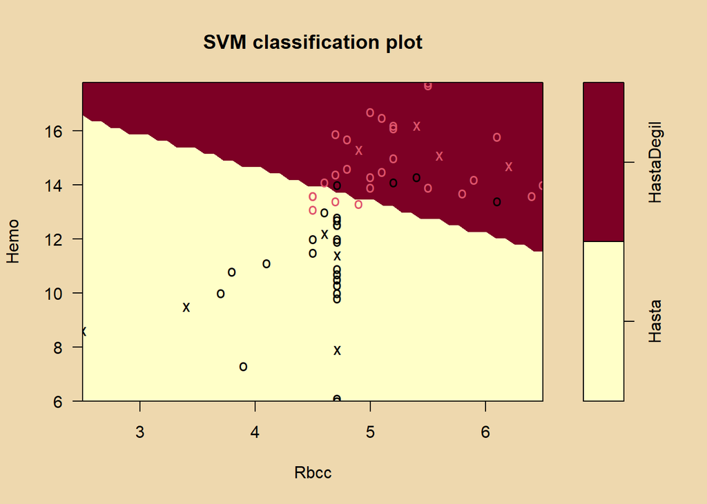

```r
op = par(bg = "wheat2")
plot(classifier4,test_set,Hemo~Rbcc)
```

Cizdirdigimiz plota baktigimizda; Gercek veride 30 tane Hasta var iken model bunlardan 26 tanesini dogru, 4 tanesini yanlis tahmin etmistir. Gercek veride 30 tane HastaDegil var iken model bunlardan 25 tanesini dogru, 5 tanesini yanlis tahmin etmistir.

En iyi modelin belirlenmesi icin SVM Cross Validation icin bir fonksiyon;

```r
set.seed(150)
cv.accuracy1 <- NULL
cv.accuracy2 <- NULL
cv.accuracy3 <- NULL
cv.accuracy4 <- NULL
k <- 30
for(i in 1:k){
index <- sample(1:nrow(veri),round(0.9*nrow(veri)))
train.cv <- veri[index,]
test.cv <- veri[-index,]

classifier1 = svm(formula = Class ~ .,
data = train.cv, scale=TRUE,
type = 'C-classification',
kernel = 'linear')
y_pred1 = predict(classifier1, newdata = test.cv[-10])
cv.accuracy1[i]<-confusionMatrix(table(test.cv[,10], y_pred1))$overall[1]

classifier2 = svm(formula = Class ~ .,
data = train.cv, scale=TRUE,
type = 'C-classification', cost=0.5,
kernel = 'linear')
y_pred2 = predict(classifier2, newdata = test.cv[-10])
cv.accuracy2[i]<-confusionMatrix(table(test.cv[,10], y_pred2))$overall[1]

classifier3 = svm(formula = Class ~ .,
data = train.cv, scale=TRUE,
type = 'C-classification',
kernel = 'radial',cost=0.7943282,gamma=0.5)
y_pred3 = predict(classifier3, newdata = test.cv[-10])
cv.accuracy3[i]<-confusionMatrix(table(test.cv[,10], y_pred3))$overall[1]

classifier4 = svm(formula = Class ~ Hemo+Rbcc,
data = train.cv, scale=TRUE,
type = 'C-classification',cost=0.5,
kernel = 'linear')
y_pred4 = predict(classifier4, newdata = test.cv[-10])
cv.accuracy4[i]<-confusionMatrix(table(test.cv[,10], y_pred4))$overall[1]
}
```

Ortalama accuracy’e bakacak olursak;

```r
mean(cv.accuracy1)
```

```
## [1] 0.9655556
```

Ortalama cv.accuracy1 degerimiz 0.9655556 cikmistir.

```r
mean(cv.accuracy2)
```

```
## [1] 0.9655556
```

Ortalama cv.accuracy2 degerimiz 0.9655556 cikmistir.

```r
mean(cv.accuracy3)
```

```
## [1] 0.98
```

Ortalama cv.accuracy3 degerimiz 0.98 cikmistir.

```r
mean(cv.accuracy4)
```

```
## [1] 0.9188889
```

Ortalama cv.accuracy4 degerimiz 0.9188889 cikmistir.

Sonuc olarak classifier3 SVM modelimizde Cost parametresini 0.7943282 ve Gamma parametresini 0.5 alip radial kernel kullanarak olusturdugumuz modelimizde en iyi dogruluk oranina ulasmis oluyoruz.